# Disease effect heterogeneity modeling in lgpr

# 3 Fitting the model

```r
fit <- lgp(
  formula = formula,
  data = dat,
  prior = list(wrp = igam(14, 5)),
  iter = 2000,
  chains = 4,
  cores = 4
)
```

Printing the fit object summarizes the posterior

```r
print(fit)
# An object of class lgpfit. See ?lgpfit for more info.
# Inference for Stan model: lgp.
# 4 chains, each with iter=2000; warmup=1000; thin=1;
# post-warmup draws per chain=1000, total post-warmup draws=4000.
#
#           mean se_mean   sd 2.5%  25%  50%  75% 97.5% n_eff Rhat
# alpha[1]  0.35    0.00 0.10 0.15 0.29 0.35 0.42  0.57  1622    1
# alpha[2]  0.75    0.01 0.36 0.33 0.50 0.66 0.90  1.73  2656    1
# alpha[3]  1.50    0.01 0.53 0.74 1.12 1.41 1.78  2.72  3945    1
# alpha[4]  0.50    0.01 0.35 0.12 0.27 0.41 0.63  1.42  3118    1
# alpha[5]  0.30    0.00 0.27 0.02 0.13 0.22 0.37  1.03  4241    1
# alpha[6]  0.38    0.00 0.30 0.05 0.19 0.30 0.47  1.22  3915    1
# ell[1]    1.51    0.03 1.54 0.46 0.83 1.13 1.67  4.94  1934    1
# ell[2]    0.68    0.01 0.31 0.15 0.46 0.66 0.87  1.33  2157    1
# ell[3]    0.91    0.01 0.66 0.12 0.40 0.77 1.23  2.63  3518    1
# ell[4]    1.93    0.03 1.64 0.38 1.04 1.56 2.29  5.79  2516    1
# ell[5]    1.85    0.05 2.44 0.16 0.57 1.04 2.12  8.19  2672    1
# ell[6]    2.33    0.05 2.68 0.33 0.92 1.51 2.77  8.97  2520    1
# wrp[1]    0.36    0.00 0.10 0.22 0.29 0.34 0.40  0.60  3373    1
# beta[1,1] 0.81    0.00 0.25 0.16 0.68 0.94 1.00  1.00  4435    1
# beta[1,2] 0.87    0.00 0.21 0.29 0.81 0.98 1.00  1.00  4705    1
# beta[1,3] 0.86    0.00 0.20 0.28 0.80 0.97 1.00  1.00  5002    1
# beta[1,4] 0.90    0.00 0.16 0.42 0.88 0.98 1.00  1.00  5430    1
# beta[1,5] 0.02    0.00 0.06 0.00 0.00 0.00 0.01  0.16  3008    1
# beta[1,6] 0.08    0.00 0.17 0.00 0.00 0.01 0.08  0.64  2639    1
# beta[1,7] 0.01    0.00 0.03 0.00 0.00 0.00 0.00  0.08  4552    1
# beta[1,8] 0.10    0.00 0.17 0.00 0.00 0.02 0.11  0.66  2649    1
# sigma[1]  0.45    0.00 0.05 0.35 0.41 0.45 0.48  0.56  2140    1
#
# Samples were drawn using NUTS(diag_e) at Thu Oct 30 21:16:56 2025.
# For each parameter, n_eff is a crude measure of effective sample size,
# and Rhat is the potential scale reduction factor on split chains (at
# convergence, Rhat=1).
```

Printing the model information clarifies the model and priors

```r
model_summary(fit)
# Formula: y ~ zs(id) * gp(age) + gp(age) + het(id) * gp_vm(diseaseAge) + zs(z1) * gp(age) + zs(z2) * gp(age) + zs(z3) * gp(age)
# Likelihood: gaussian
# Data: 96 observations, 7 variables
#
#                   Component type ker het ns vm unc cat cont
# 1            zs(id)*gp(age)    2   0   0  0  0   0   1    1
# 2                   gp(age)    1   0   0  0  0   0   0    1
# 3 het(id)*gp_vm(diseaseAge)    1   0   1  1  1   0   0    2
# 4            zs(z1)*gp(age)    2   0   0  0  0   0   2    1
# 5            zs(z2)*gp(age)    2   0   0  0  0   0   3    1
# 6            zs(z3)*gp(age)    2   0   0  0  0   0   4    1
#
#     Variable #Missing
# 1        age        0
# 2 diseaseAge       48
#
#   Factor #Levels Values
# 1     id      16    ...
# 2     z1       2   1, 2
# 3     z2       2   1, 2
# 4     z3       2   1, 2
#
#    Parameter   Bounds                         Prior
# 1   alpha[1] [0, Inf)      alpha[1] ~ student-t(20)
# 2   alpha[2] [0, Inf)      alpha[2] ~ student-t(20)
# 3   alpha[3] [0, Inf)      alpha[3] ~ student-t(20)
# 4   alpha[4] [0, Inf)      alpha[4] ~ student-t(20)
# 5   alpha[5] [0, Inf)      alpha[5] ~ student-t(20)
# 6   alpha[6] [0, Inf)      alpha[6] ~ student-t(20)
# 7     ell[1] [0, Inf)      ell[1] ~ log-normal(0,1)
# 8     ell[2] [0, Inf)      ell[2] ~ log-normal(0,1)
# 9     ell[3] [0, Inf)      ell[3] ~ log-normal(0,1)
# 10    ell[4] [0, Inf)      ell[4] ~ log-normal(0,1)
# 11    ell[5] [0, Inf)      ell[5] ~ log-normal(0,1)
# 12    ell[6] [0, Inf)      ell[6] ~ log-normal(0,1)
# 13    wrp[1] [0, Inf)      wrp[1] ~ inv-gamma(14,5)
# 14  sigma[1] [0, Inf) (sigma[1])^2 ~ inv-gamma(2,1)
# 15 beta[1-8]   [0, 1]    beta[1-8] ~ beta(0.2, 0.2)
#
#
# id                     1 2 3 4 5 6 7 8
# beta_or_teff_param_idx 1 2 3 4 5 6 7 8
#
# Created on Thu Oct 30 21:12:44 2025 with lgpr 1.2.5.
```

## 3.1 Visualizing the individual-specific effect magnitudes

We can visualize the posterior distribution of the individual-specific disease effect magnitude parameters for each case individual. We see that for individuals 1-4 the parameters are close to 1 (affected individuals) and for individuals 5-8 there is considerable posterior mass close to 0.

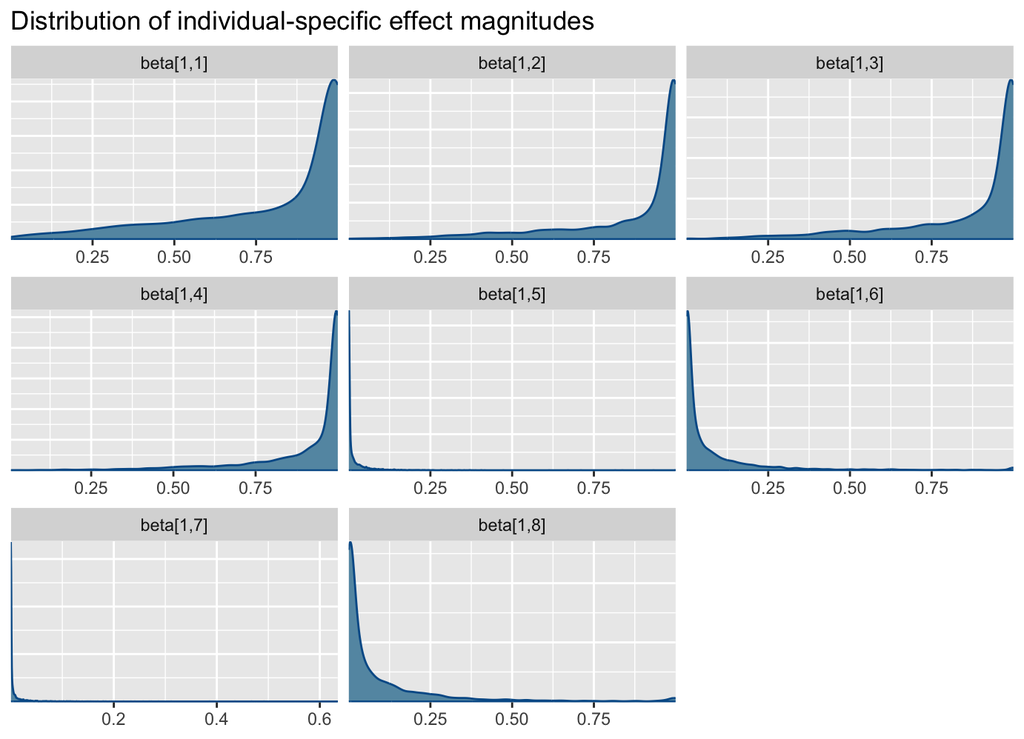

```r
plot_beta(fit)
#
# id                     1 2 3 4 5 6 7 8
# beta_or_teff_param_idx 1 2 3 4 5 6 7 8
```

# 4 Visualizing the inferred heterogeneous effect

Finally we plot the inferred disease component, using posterior median hyperparameters, and see that the inferred effects have the same shape for all individuals, but are heterogeneous in magnitude.

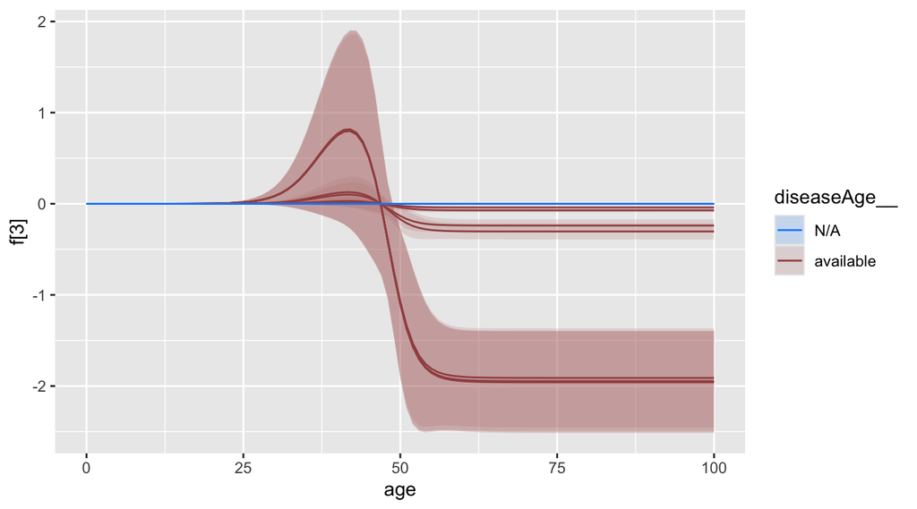

```r
t <- seq(0, 100, by = 1)
x_pred <- new_x(dat, t, x_ns = "diseaseAge")
p <- pred(fit, x_pred, verbose = FALSE, reduce = stats::median)
plot_f(fit, pred = p, comp_idx = 3, color_by = "diseaseAge")
```

# 5 Computing environment

```r
sessionInfo()
# R version 4.4.1 (2024-06-14)
# Platform: aarch64-apple-darwin20
# Running under: macOS Sonoma 14.6.1
#
# Matrix products: default
# BLAS:   /Library/Frameworks/R.framework/Versions/4.4-arm64/Resources/lib/libRblas.0.dylib
# LAPACK: /Library/Frameworks/R.framework/Versions/4.4-arm64/Resources/lib/libRlapack.dylib;  LAPACK version 3.12.0
#
# locale:
# [1] C/UTF-8/C/C/C/C
#
# time zone: Europe/Helsinki
# tzcode source: internal
#
# attached base packages:
# [1] stats     graphics  grDevices utils     datasets  methods   base
#
# other attached packages:
# [1] rstan_2.32.7        StanHeaders_2.32.10 ggplot2_4.0.0
# [4] lgpr_1.2.5          rmarkdown_2.30
#
# loaded via a namespace (and not attached):
#  [1] tensorA_0.36.2.1      sass_0.4.10           generics_0.1.4
#  [4] stringi_1.8.7         digest_0.6.37         magrittr_2.0.4
#  [7] evaluate_1.0.5        grid_4.4.1            RColorBrewer_1.1-3
# [10] fastmap_1.2.0         plyr_1.8.9            jsonlite_2.0.0
# [13] pkgbuild_1.4.8        backports_1.5.0       gridExtra_2.3
# [16] QuickJSR_1.8.1        scales_1.4.0          codetools_0.2-20
# [19] jquerylib_0.1.4       abind_1.4-8           cli_3.6.5
# [22] crayon_1.5.3          rlang_1.1.6           withr_3.0.2
# [25] cachem_1.1.0          yaml_2.3.10           tools_4.4.1
# [28] inline_0.3.21         parallel_4.4.1        reshape2_1.4.4
# [31] checkmate_2.3.3       rstantools_2.5.0      dplyr_1.1.4
# [34] colorspace_2.1-2      curl_6.2.3            posterior_1.6.1
# [37] vctrs_0.6.5           R6_2.6.1              matrixStats_1.5.0
# [40] stats4_4.4.1          lifecycle_1.0.4       stringr_1.5.2
# [43] V8_6.0.0              MASS_7.3-60.2         pkgconfig_2.0.3
# [46] RcppParallel_5.1.11-1 pillar_1.11.1         bslib_0.9.0
# [49] gtable_0.3.6          loo_2.8.0             glue_1.8.0
# [52] Rcpp_1.1.0            xfun_0.53             tibble_3.3.0
# [55] tidyselect_1.2.1      knitr_1.50            farver_2.1.2
# [58] bayesplot_1.14.0      htmltools_0.5.8.1     labeling_0.4.3
# [61] compiler_4.4.1        S7_0.2.0              distributional_0.5.0
```